# Clustering of time series (Fixed one job, one region)

Leanne Dong

03/09/2019

## Clustering

Time series clustering is to partition time series data into groups based on similarity or distance, so that time series in the same cluster are similar. For time series clustering with R, the *first step* is to work out an appropriate distance/similarity metric for the correlation, and then, at the *second step*, we use an clustering structures using the $k$-Medoids clustering algorithm.

First, clear the workspace and load the required packages

```r
rm(list = ls(all.names = TRUE))
# List of packages for session
.pks<- c("tidyverse","magrittr","factoextra","cluster","gcmr")
# Install CRAN packages (if not already installed)
.inst<- .pks %in% installed.packages()
if(length(.pks[!.inst])>0) install.packages(.pks[!.inst])
# load packages into session
lapply(.pks,require,character.only=TRUE)
```

```
## [[1]]
## [1] TRUE
##
## [[2]]
## [1] TRUE
##
## [[3]]
## [1] TRUE
##
## [[4]]
## [1] TRUE
##
## [[5]]
## [1] TRUE
```

```r
 source("scripts/nloptr.R")
```

Our first step is to get the correlation of job counts between regions. To this end we need to do some data wrangling.

```r
#setwd("/home/ledong/Data/taxonomy")
#require(tidyverse)
#df <- read_csv("data/df_sa_1.csv")
data <- read_csv("data/DatasetADZUNA_V6.csv")
glimpse(data)
```

```
## Observations: 7,280,145
## Variables: 16
## $ id                <dbl> 469712826, 469712828, 469712830, 469712831, 46…
## $ Original_Title    <chr> "Insurance Lawyer", "Shipping and Logistics Co…
## $ Year              <dbl> 2016, 2016, 2016, 2016, 2016, 2016, 2016, 2016…
## $ Month             <dbl> 12, 12, 12, 12, 12, 12, 12, 12, 12, 12, 12, 12…
## $ SA2_ABS_MATCH     <chr> NA, NA, NA, "Melbourne", NA, NA, "Melbourne", …
## $ SA3_ABS_MATCH     <chr> NA, "Warringah", NA, "Melbourne City", "Camden…
## $ SA4_ABS_MATCH     <chr> "Sydney - City and Inner South", "Sydney - Nor…
## $ GCCSA_ABS_MATCH   <chr> "Greater Sydney", "Greater Sydney", "Greater S…
## $ LGA_ABS_MATCH     <chr> "Sydney", NA, "Sydney", NA, NA, NA, NA, NA, NA…
## $ STATE_ABS_MATCH   <chr> "New South Wales", "New South Wales", "New Sou…
## $ site_name         <chr> "CareerOne.com.au", "CareerOne.com.au", "Caree…
## $ category          <chr> "Legal", "Retail / wholesale", "Accounting / F…
## $ contract_type     <chr> "permanent", "permanent", "permanent", "perman…
## $ contract_time     <chr> "full_time", "full_time", "full_time", "full_t…
## $ ANZSCO1digit_BERT <dbl> 5, 1, 2, 5, 2, 7, 6, 2, 2, 6, 2, 4, 1, 3, 2, 2…
## $ ANZSCO4digit_BERT <dbl> 5523, 1336, 2211, 5511, 2411, 7331, 6393, 2332…
```

```r
str(data)
```

```
## Classes 'spec_tbl_df', 'tbl_df', 'tbl' and 'data.frame': 7280145 obs. of  16 variables:
##  $ id               : num  4.7e+08 4.7e+08 4.7e+08 4.7e+08 4.7e+08 ...
##  $ Original_Title   : chr  "Insurance Lawyer" "Shipping and Logistics Coordinator" "Technical Financial Accountant" "Senior Administrator Managed Accounts, Custom Solutions Customer Services (Melbourne)" ...
##  $ Year             : num  2016 2016 2016 2016 2016 ...
##  $ Month            : num  12 12 12 12 12 12 12 12 12 12 ...
##  $ SA2_ABS_MATCH    : chr  NA NA NA "Melbourne" ...
##  $ SA3_ABS_MATCH    : chr  NA "Warringah" NA "Melbourne City" ...
##  $ SA4_ABS_MATCH    : chr  "Sydney - City and Inner South" "Sydney - Northern Beaches" "Sydney - City and Inner South" "Melbourne - Inner" ...
##  $ GCCSA_ABS_MATCH  : chr  "Greater Sydney" "Greater Sydney" "Greater Sydney" "Greater Melbourne" ...
##  $ LGA_ABS_MATCH    : chr  "Sydney" NA "Sydney" NA ...
##  $ STATE_ABS_MATCH  : chr  "New South Wales" "New South Wales" "New South Wales" "Victoria" ...
##  $ site_name        : chr  "CareerOne.com.au" "CareerOne.com.au" "CareerOne.com.au" "CareerOne.com.au" ...
##  $ category         : chr  "Legal" "Retail / wholesale" "Accounting / Finance" "Accounting / Finance" ...
##  $ contract_type    : chr  "permanent" "permanent" "permanent" "permanent" ...
##  $ contract_time    : chr  "full_time" "full_time" "full_time" "full_time" ...
##  $ ANZSCO1digit_BERT: num  5 1 2 5 2 7 6 2 2 6 ...
##  $ ANZSCO4digit_BERT: num  5523 1336 2211 5511 2411 ...
##  - attr(*, "spec")=
##   .. cols(
##   ..   id = col_double(),
##   ..   Original_Title = col_character(),
##   ..   Year = col_double(),
##   ..   Month = col_double(),
##   ..   SA2_ABS_MATCH = col_character(),
##   ..   SA3_ABS_MATCH = col_character(),
##   ..   SA4_ABS_MATCH = col_character(),
##   ..   GCCSA_ABS_MATCH = col_character(),
##   ..   LGA_ABS_MATCH = col_character(),
##   ..   STATE_ABS_MATCH = col_character(),
##   ..   site_name = col_character(),
##   ..   category = col_character(),
##   ..   contract_type = col_character(),
##   ..   contract_time = col_character(),
##   ..   ANZSCO1digit_BERT = col_double(),
##   ..   ANZSCO4digit_BERT = col_double()
##   .. )
```

We first look at time series represents volumes of job ads **per occupations** (time series corresponds to regions). We now cluster per **Occupation**.

```r
require(parallel)
data$mth.no <- (data$Year -2015)*12 + data$Month
f1 <- function(i,dt){
  dt %>% filter(SA4_ABS_MATCH==i) %>% group_by(ANZSCO1digit_BERT,mth.no, Month) %>% count() %>% spread(ANZSCO1digit_BERT, n) %>% mutate(Regions = i) %>% ungroup()
}
.cl <- makeCluster(spec = detectCores(), type = "FORK")
df_1 <- as.data.frame(do.call(rbind,(parLapply(cl=.cl, X= unique(data$SA4_ABS_MATCH),f1, dt=data)))) %>% rename(x1="1",x2="2",x3="3",x4="4",x5="5",x6="6",x7="7",x8="8")
dim(df_1)
```

```
## [1] 4488   11
```

```r
#View(df_1)
```

Now I would like to model related occupations using a copulas We first need to classify regions. To this end, we will examine the dependence of time series acorss regions by computing the similarity and dissimilarity metrics.

```r
df_r <- df_1 %>% select("mth.no","x1","Regions") %>% spread(key=Regions, value = x1 )%>% replace(.,is.na(.),0)
dim(df_r)
```

```
## [1] 51 89
```

Compute the matrix of similarity.

```r
#mat <- qld %>% dplyr::select(-Region)
c <- cor(df_r[,2:89])
#as.matrix(c)[1:8,1:8]
```

Now we compute the matrix of dissimilarity, which is essentially a correlation-based distance matrix.

```r
#c_s <- c#[1:8, 1:8]
c_s <- scale(c)
d <- as.dist((1-c_s)/ max(1-c_s))
dim(as.matrix(d))
```

```
## [1] 88 88
```

```r
as.matrix(d)[1:8,1:8]
```

```
##                              Adelaide - Central and Hills Adelaide - North
## Adelaide - Central and Hills                   0.00000000       0.38289201
## Adelaide - North                               0.38289201       0.00000000
## Adelaide - South                               0.17876802       0.17940871
## Adelaide - West                                0.19332616       0.09118975
## Australian Capital Territory                  -0.13984516       0.39197398
## Ballarat                                       0.03368305       0.14343244
## Barossa - Yorke - Mid North                    0.41883231      -0.01217707
## Bendigo                                        0.23434768       0.04645131
##                              Adelaide - South Adelaide - West
## Adelaide - Central and Hills      0.178768017      0.19332616
## Adelaide - North                  0.179408709      0.09118975
## Adelaide - South                  0.000000000     -0.31971361
## Adelaide - West                  -0.319713607      0.00000000
## Australian Capital Territory      0.127373483      0.19252168
## Ballarat                         -0.001436481      0.21339165
## Barossa - Yorke - Mid North       0.261216216      0.32978880
## Bendigo                           0.202475344      0.31435536
##                              Australian Capital Territory      Ballarat
## Adelaide - Central and Hills                 -0.139845160  0.0336830487
## Adelaide - North                              0.391973984  0.1434324447
## Adelaide - South                              0.127373483 -0.0014364812
## Adelaide - West                               0.192521681  0.2133916534
## Australian Capital Territory                  0.000000000  0.0015963225
## Ballarat                                      0.001596323  0.0000000000
## Barossa - Yorke - Mid North                   0.427792906 -0.0007860794
## Bendigo                                       0.103955625 -0.1267846283
##                              Barossa - Yorke - Mid North     Bendigo
## Adelaide - Central and Hills                0.4188323091  0.23434768
## Adelaide - North                           -0.0121770717  0.04645131
## Adelaide - South                            0.2612162161  0.20247534
## Adelaide - West                             0.3297887990  0.31435536
## Australian Capital Territory                0.4277929061  0.10395563
## Ballarat                                   -0.0007860794 -0.12678463
## Barossa - Yorke - Mid North                 0.0000000000  0.02304339
## Bendigo                                     0.0230433856  0.00000000
```

The silhouette plot displays a measure of how close each point in one cluster is to points in the neighboring clusters.

```r
pamd <- cluster::pam(x = d, k = 8, diss = T)
print(pamd)
```

```
## Medoids:
##      ID
## [1,] "82" "Townsville"
## [2,] "88" "Wide Bay"
## [3,] "56" "Perth - South East"
## [4,] "77" "Sydney - Parramatta"
## [5,] "29" "Illawarra"
## [6,] "25" "Gold Coast"
## [7,] "86" "Western Australia - Outback (South)"
## [8,] "79" "Sydney - South West"
## Clustering vector:
##           Adelaide - Central and Hills
##                                      1
##                       Adelaide - North
##                                      2
##                       Adelaide - South
##                                      3
##                        Adelaide - West
##                                      4
##           Australian Capital Territory
##                                      5
##                               Ballarat
##                                      1
##            Barossa - Yorke - Mid North
##                                      2
##                                Bendigo
##                                      2
##                        Brisbane - East
##                                      4
##                       Brisbane - North
##                                      3
##                       Brisbane - South
##                                      6
##                        Brisbane - West
##                                      4
##                    Brisbane Inner City
##                                      3
##                                Bunbury
##                                      2
##                                 Cairns
```

[output cut: 139 more lines]

```
##    Western Australia - Outback (North)
##                                      7
##    Western Australia - Outback (South)
##                                      7
##         Western Australia - Wheat Belt
##                                      2
##                               Wide Bay
##                                      2
## Objective function:
##      build       swap
## -0.1083072 -0.1083072
##
## Available components:
## [1] "medoids"    "id.med"     "clustering" "objective"  "isolation"
## [6] "clusinfo"   "silinfo"    "diss"       "call"
```

```r
# extract the cluster.
#pamd$medoids
## printing the ``clustering vector''
clust.vec <- lapply(1:10, function(nc) colnames(df_r[,2:89])[pamd$clustering==nc])
print(clust.vec)
```

```
## [[1]]
##  [1] "Adelaide - Central and Hills" "Ballarat"
##  [3] "Cairns"                       "Darwin"
##  [5] "Geelong"                      "Logan - Beaudesert"
##  [7] "Newcastle and Lake Macquarie" "Perth - Inner"
##  [9] "Sydney - Inner South West"    "Sydney - Sutherland"
## [11] "Toowoomba"                    "Townsville"
##
## [[2]]
##  [1] "Adelaide - North"
##  [2] "Barossa - Yorke - Mid North"
##  [3] "Bendigo"
##  [4] "Bunbury"
##  [5] "Central Queensland"
##  [6] "Central West"
```

[output cut: 79 more lines]

```
##   cluster size ave.sil.width
## 1       1   12          0.09
## 2       2   20          0.38
## 3       3    7         -0.05
## 4       4    8          0.44
## 5       5    6          0.67
## 6       6    4          0.25
## 7       7   21          0.91
## 8       8   10          0.14
```

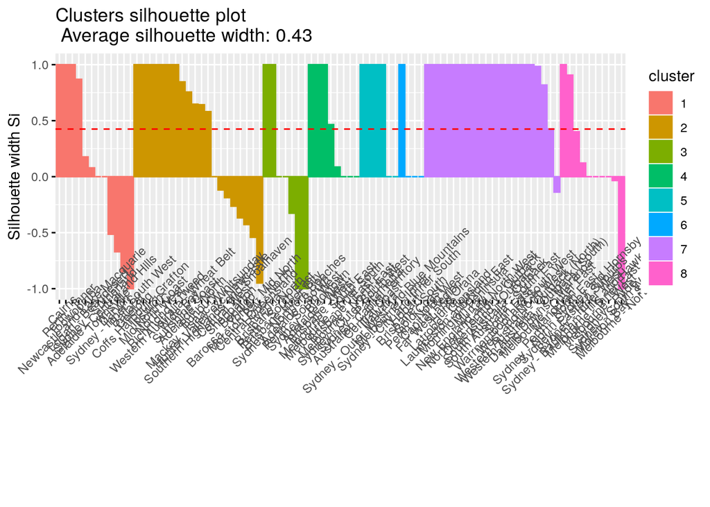

```r
# the following never work
# fviz_nbclust(as.list(d), pam, method = "wss") + geom_vline(xintercept = 4, linetype = 2)
# plot a graphic showing the cluster and the medoids of each cluster
#ssi <- summary(pamd)
fviz_silhouette(pamd,label=TRUE)
```

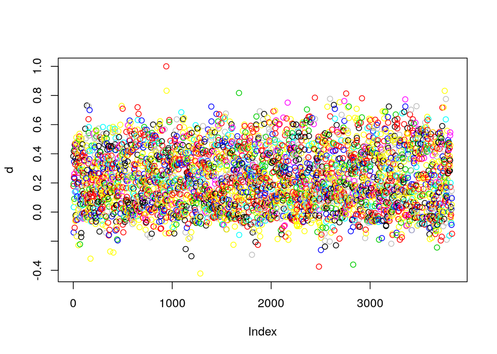

```r
plot(d,col=pamd$clustering)
```

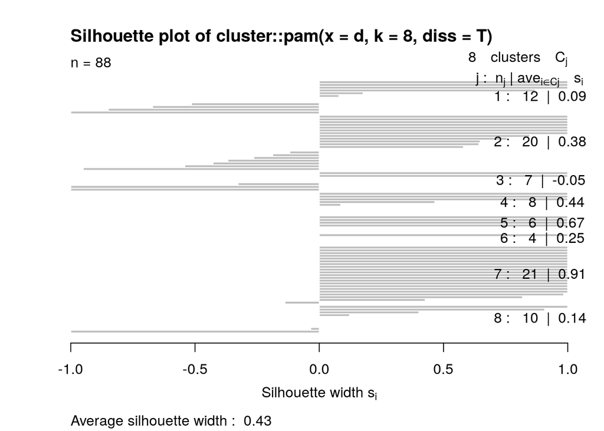

```r
#points(pamd$memoids,col=1:2,pch=4)
plot(pamd)
```

```r
df_c1 <- df_1 %>% filter(Regions %in% clust.vec[[1]])
df_c2 <- df_1 %>% filter(Regions %in% clust.vec[[2]])
df_c3 <- df_1 %>% filter(Regions %in% clust.vec[[3]])
df_c4 <- df_1 %>% filter(Regions %in% clust.vec[[4]])
df_c5 <- df_1 %>% filter(Regions %in% clust.vec[[5]])
df_c6 <- df_1 %>% filter(Regions %in% clust.vec[[6]])
df_c7 <- df_1 %>% filter(Regions %in% clust.vec[[7]])
df_c8 <- df_1 %>% filter(Regions %in% clust.vec[[8]])
```

Now we take cluster 7, and fit copulas.

```r
fit1 <- gcmr(x8 ~ (mth.no + cos(mth.no * 2 * pi/12)+ sin(mth.no * 2 * pi/12))*as.factor(Regions == "South East") + as.factor(Month==11), data = df_c7,  marginal=negbin.marg, cormat = arma.cormat(1,0), options = list(seed = round(runif(1, 1, 1e+05)), nrep = c(100, 1000), no.se = FALSE, opt = myopt))
fit1$convergence <- 0
AIC(fit1)
```

```
## [1] 8989.736
```

We now seek to find a feature set that yields the lowest AIC. Let start with cluster 1, that is `df_c1`. Sadly does not work- Error: `Error in jhess(m) : impossible to compute a finite jacobian`.

```r
dvar1 <- df_c1$x1
dvar2 <- df_c1$x2
dvar3 <- df_c1$x3
dvar4 <- df_c1$x4
dvar5 <- df_c1$x5
dvar6 <- df_c1$x6
dvar7 <- df_c1$x7
dvar8 <- df_c1$x8

ivar1 <- df_c1$mth.no
temp2 <- df_c1 %>% select(mth.no) %>% mutate(cosmth=cos(mth.no * 2 * pi/12))
ivar2 <- temp2$cosmth
temp3 <- df_c1 %>% select(mth.no) %>% mutate(sinmth=sin(mth.no * 2 * pi/12))
ivar3 <- temp3$sinmth
ivar4 <- df_c1$Regions
ivar5 <- df_c1$Regions[1]
ivar6 <- df_c1$Regions[2]
ivar7 <- df_c1$Regions[3]
ivar8 <- df_c1$Regions[4]
ivar9 <- df_c1$Regions[5]
ivar10 <- df_c1$Regions[6]
ivar11 <- df_c1$Regions[7]
ivar12 <- df_c1$Regions[8]
ivar13 <- df_c1$Regions[9]
ivar14 <- df_c1$Regions[10]
#ivar15 <- df_c1$

d_vars <- paste("dvar", 1:6, sep="")
i_vars <- paste("ivar", 1:14, sep="")

# create all combinations of ind_vars
ind_vars_comb <-
  unlist( sapply( seq_len(length(i_vars)),
                  function(i) {
                    apply( combn(i_vars,i), 2, function(x) paste(x, collapse = "+"))
                  }))

# pair with dep_vars:
var_comb <- expand.grid(d_vars, ind_vars_comb )

# formulas for all combinations
formula_vec <- sprintf("%s ~ %s", var_comb$Var1, var_comb$Var2)

# create models
gcmr_res <- lapply( formula_vec, function(f)   {
  fit1 <- gcmr( f, data = df_c1, marginal = negbin.marg,cormat = arma.cormat(2,1),options = list(seed=round(runif(1,1,1e+05)),nrep=c(100,1000),no.se=FALSE,opt=myopt))
  fit1$convergence <- 0
#  fit1$coefficients <- coef( summary(fit1))
  fit1$aic<- AIC(fit1)
  return(fit1$aic)
})
#names(gcmr_res) <- formula_vec

aics_x1<-as.data.frame(cbind(formula_vec,gcmr_res))
aics_x1
rownames(aics_x1)[which.min(aics_x1[,2])]
```